# Networks as a Data Vizulation Tool to Understand Rater Differences

Andrew J. Kelly

1 May 2022

## What is a network?

In a basic definition, a network are connections between variables. Everyone has a general understanding of this in friend groups. Think back to high school cliques. You have the athletic kids, the smart kids, the edgy kids, the loners, etc. Each of them is a group, with each person within the group being considered a node. These nodes are interconnected within the group, they’re friends with each other. Sometimes though, you get someone who can transcend the ‘group’ label. It could be a smart kid who is also a loner, or an edgy kid that is also an athlete. Here, we see the two groups begin to interact with each other through that singular node (i.e., the kid which is in two groups and not just one). However, there is no reason to consider this relationship between the two groups to be strong from this one node. However, the nodes in the two groups may be strong with the kid who is within both groups. That is, Tommy the Edgy Athlete might be close with Jana the Athlete and Edgy Billy, but Tommy the Edgy Athlete is **not** close to Bobby the Athlete or Edgy Sammy. This is called the edge, the connection itself and the strength associated with it.

#### How do psychological scientists use networks?

Modern psychological science has started to use networks to better understand clinical symptoms in context of the individual person. A binary diagnosis (i.e., diagnoses/not diagnosed) does not provide as much information as understanding the underlying symptoms when it comes to potential treatment options. If a person has been diagnosed with Major Depressive Disorder, the actual diagnosis does not inform how a clinician should interact with the diagnosis other than in a generality (e.g., individual reports they feel worthless, are suicidal, etc.. Networks allow for a clinician to understand what symptoms are prominent and, more importantly, how they might be interacting with each other:

> James comes in for a therapy sessions to discuss their recent depression diagnosis. Previous to James coming in, they filled out a few forms asking about their symptoms. These forms are compiled an a network analysis are ran. As James comes in for their first session, they believe their recent problems are entirely due to their lack of energy. The network analysis reveals the lack of energy is not biggest issue. Instead, it is the feeling of worthlessness James feels about theirself. This feeling of worthlessness is also strongly connected to insomnia, lack of pleasure, and difficulty concentrating.

The above situation gives and example of how network analyses can be useful. There are many scientists working on how we utilize network analyses to benefit clinical science - [Eiko Fried](https://twitter.com/EikoFried) and [Sacha Epskamp](https://twitter.com/SachaEpskamp) are two highly respected researchers doing this.

All this said, I tend to like to [break](https://twitter.com/andjkel/status/1403516766811209729?s=20) or [find other uses](https://andjkel.github.io/pages/Participant-Privacy-Highly-Synthetic-Data.html) for previously established concepts. So, what if we had James’ significant other and their best friend *also* do the forms asking about James’ symptoms?

## James’ Symptoms Networks

As described, James, their significant other, and their best friend completed the forms to ascertain James’ symptoms. The network analysis reveals some very interesting results for each individual.

#### James’ Reported Symptoms

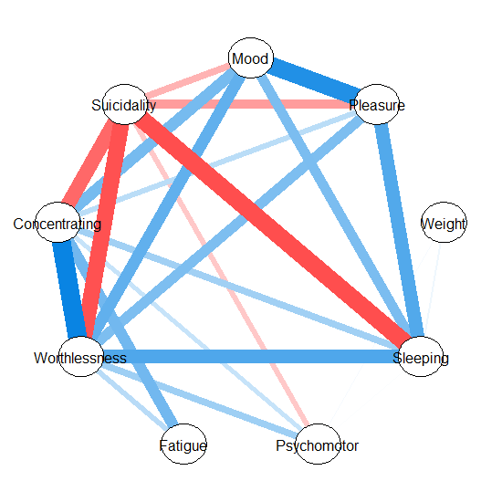

The above image is what James reported for their symptoms. Red edges (lines) indicate a negative relationship between the variables, with the width/opacity of the edge (line) indicating a stronger relationship. As an example, there is a strong, negative relationship between James’ suicidality and their sleeping issues. However, there is a strong, positive relationship between their daily mood and lack of pleasure they are experiencing. A clinician may notice how interconnected James’ worthlessness is with the other variables and begin to tackle the problematic areas with that:

- Worthlessness ↔︎ Concentrating
- Worthlessness ↔︎ Sleeping Issues
- Worthlessness ↔︎ Pleasure
- Worthlessness ↔︎ Daily Mood

#### Significant Other’s Reported Symptoms for James

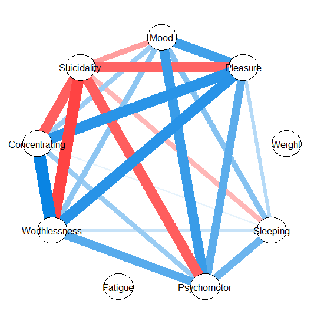

James’ significant other’s reports of James’ symptoms brings out a new variable to consider for the clinician: psychomotor. Perhaps James has been unaware of their delayed behaviors. James might be passing off the cognitive slowing due to their reported lack of energy and not considering it as a factor in their depressive symptoms in and of itself. However, James’ significant other has noticed the cognitive delays - such as taking longer than usual to respond to simple questions - alongside physical delays (e.g., walking slower than usual).

#### Best Friend’s Reported Symptoms for James

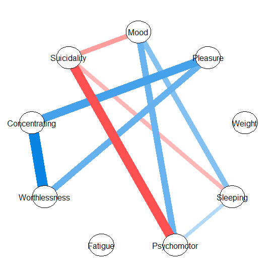

James’ best friend’s network for James’ symptoms looks extremely different than the networks provided by James or James’ significant other. Yet, there is still important information which can be obtained from it. This is the third individual involved with this treatment of James which has a strong, positive relationship between feelings of worthlessness and concentration issues. A clinician should take note of this and set aside an area to effectively investigate this relationship and determine what can be done to mitigate the issues the two may be causing.

## Other Uses for Network Analyses for Data Vizualiation

This is just a singular example of possible ways to utilize network analyses as a data vizualation tool to understand the underlying data dynamics. One example where two uses may occur is in behavioral ratings of students by teachers. It is becoming more common that teachers rate the behaviors of their students in an effort to identify problematic behaviors so adequate and timely identification of disorders and ‘correctable’[3] behaviors can occur. Here are the two possible uses for doing a network analysis on such an example:

1. If a classroom were to have multiple teachers, or a singular student have multiple teachers, then it would be possible to use the information observed from network analyses to inform on best practices to manage the problematic behaviors. On the classroom level, it may inform on classroom/behavior management skills and potential training areas. Teacher A may have multiple negative behaviors with complex data dynamics which might need training, but Teacher B may have multiple positive behaviors with simple data dynamics. It might be worthwhile for Teacher B to observe Teacher A and help traing Teacher A later to manage these concerns.
2. If a teacher has a bias against a student and their behaviors, it is possible to observe this. Student A gets reported frequently to the principal for misbehavior. The school social worker or psychologist decides to do a network analysis to do what the previous example is intending to do. However, instead of this the school social worker or psychologist finds that Teacher C often reports that Student A’s behaviors are much more aggressive than Teacher A or Teacher B report. In fact, all of the negative behaviors are strong within the network analysis and only by the reports from Teacher C. Here, the data report a bias against the teacher’s behavior[4].

### Notes

[1] Thank you to [Eiko Fried](https://twitter.com/EikoFried) for talking with me about [using network analyses as an aesthetic](https://doi.org/10.1525/collabra.24085) component into understanding variables.

[2] This should be obvious, but I am not any sort of licensed, certified, or professional qualified to begin to make judgements on clinical treatment or diagnoses of possible mental health disorders.

[3] Really don’t like this phrasing.

[4] Technically speaking, this is a subjective inference. The other possible alternative is that Student A only has problems with Teacher C, but the example given is also entirely possible.